# Tale of War

Cynthia Clement & Vineet Aguiar

```r
## Load Packages
library(ggplot2)
library(grid)
library(gridExtra)
library(tidyr)
library(dplyr)
library(viridis)
library(gtools)
library(RColorBrewer)
##import data
#NMC
NMC_orig = read.csv("./data/NMC/NMC_v4_0.csv", sep= ",")
#Alliances
dyad_al_0= read.csv("./data/version4.1_csv/alliance_v4.1_by_dyad.csv", sep= ",")
dyad_al_year = read.csv("./data/version4.1_csv/alliance_v4.1_by_dyad_yearly.csv", sep= ",")
member_alliances = read.csv("./data/version4.1_csv/alliance_v4.1_by_member.csv", sep= ",")
member_al_year = read.csv("./data/version4.1_csv/alliance_v4.1_by_member_yearly.csv", sep= ",")
dir_al_year= read.csv("./data/version4.1_csv/alliance_v4.1_by_directed_yearly.csv", sep= ",")
dir_al= read.csv("./data/version4.1_csv/alliance_v4.1_by_directed.csv", sep= ",")
## Events Data Frame
d=data.frame(x1=c(1914,1939, 1947, 1950, 1955, 2001), x2=c(1918, 1945, 1991, 1953, 1975, 2010), Conflict=c("WWI", "WWII", "Cold War", "Korean War", "Vietnam War", "Afghanistan War"), r=c(1,2,3,4,5,6))
```

## Introduction

**Overview**  
Wars are complex events born of geopolitical, cultural or economic strife, oftentimes spanning many years but ultimately costing us lives, our livelihood and peace. During wars, countries quickly adopt ideologies, form allegiances, and discipline their economic and scientific priorities while maintaining their military focus with a blind adherence. Although the causes of this displacement of peace may vary, is there a precursory pattern to it? Does the landscape change after the end of a prolonged conflict? Do certain actors benefit more? Do some lose more than others? And most importantly, could there be important predictors of these epic events that change the course of history?

**Our Aim**  
We are particularly interested in studying the changes that happen to a country before and after they enter a war. We want to see the change of alliances and strategies, it’s impact on trade and commerce and the economics at play. We also want to compare and contrast the characteristics of countries who won wars with the ones that lost. Our eventual goal is to find certain factors that indicate which countries will enter into a war and how these factors/predictors change over time.

**Scope and Timeline**  
To limit our scope we will explore the data with a particular emphasis on the United States of America and the wars it has fought since 1900. At various points, we may have to include comparisons between countries and the US and we will explore the data breadth-wise to draw meaningful insights.

For our timeline, we plan to look at events/activity leading to, during and following the major US wars, namely;  
WWI ————————– 1914-1918  
WWII ————————- 1939-1945  
Cold War ——————– 1947-1991  
Korean War —————- 1950-1953  
Vietnam War ————— 1955-1975  
War in Afghanistan ——- 2001-2010

## The Data, Team Members and The Roles

The [Correlates of War Project](http://www.correlatesofwar.org) is a treasure trove of information. We have a special interest in the following datasets: Trade, National Materials Capabilities, Alliances and Militarized Interstate Disputes.

**Our Plan**  
We’ve decided to divide and conquer the work by each taking a subset of the data and exploring it. After sometime, we will regroup to see what we’ve learnt so far and switch data sets amongst ourselves to see if there are more insights to be learnt or different approaches to visualize the existing data. Lastly, we want to drill down into particular variables and plot correlations or predictors for the final output.

*Phase 1:*  
* Cynthia to analyze National Materials Capabilities and Alliances  
* Vineet to analyze Militarized Interstate Disputes and Trade

*Phase 2:*  
* We are going to switch the data sets we are looking at to see if the other person can discern any new insights or creative ways of presenting the data.  
+ Cynthia to analyze Militarized Interstate Disputes and Trade  
+ Vineet to analyze National Materials Capabilities and Alliances

*Phase 3:* * Cynthia and Vineet to come together and look at the interaction of different variables. For example how did a change in trade impact the NMC.

## Analysis of Data Quality

**Provide a detailed, well-organized description of data quality, including textual description, graphs, and code.**

**Overall**

Overall the consistency of these data sets is quite good. We have not found any evidence of conflicting information.

**National Materials Capabilities**

The overall data quality of NMC dataset is very good. There are roughly 14,000 entries and 89% of them did not have any missing values. There is one data entry for each country per year. The accuracy of the data is also very good because as countries are dissolved and new ones are formed, this data keeps track of them. For example, the graph depicts the CINC of Austria-Hungary from 1900-1918, the end of WWI when it the Austro-Hungarian Empire was dissolved. Immediately after that, you see data points for Austria and Hungary separately.

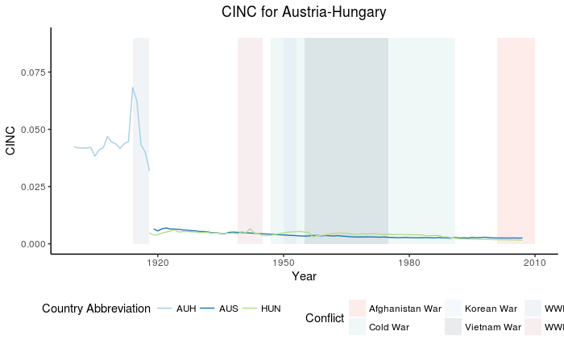

```r
NMC_test <- NMC_orig
NMC_test$cinc[NMC_test$cinc == -9] <- NA
NMC_test$irst[NMC_test$irst == -9] <- NA
NMC_test$milex[NMC_test$milex == -9] <- NA
NMC_test$milper[NMC_test$milper== -9] <- NA
NMC_test$pec[NMC_test$pec == -9] <- NA
NMC_test$tpop[NMC_test$tpop == -9] <- NA
NMC_test$upop[NMC_test$upop == -9] <- NA
NMC_test <- filter(NMC_test, NMC_test$year %in% c(1900:2007))
test <- c("Austria-Hungary", "Austria", "Hungary")
test_ccode <- member_alliances$ccode[match(test, member_alliances$state_name)]
NMC_test <- filter(NMC_test, NMC_test$ccode %in% test_ccode)
ggplot() +
  scale_x_continuous(name="Year") +
  scale_y_continuous(name="CINC") +
  labs(color ='Country Abbreviation')+
  geom_rect(data=d, mapping=aes(xmin=x1, xmax=x2, ymin=0, ymax=.09, fill=Conflict),alpha=0.15) +
  geom_line(data = NMC_test, aes(x = year, y = cinc, color = stateabb, group = stateabb)) +
  ggtitle("CINC for Austria-Hungary") +
  theme_classic()+
  scale_fill_manual(values=c("salmon", "paleturquoise3", "lightsteelblue2", "lightsteelblue4", "lightsteelblue3", "pink3"))+
  scale_color_brewer(palette="Paired")+
  theme(plot.title = element_text(hjust = .5), legend.position = "bottom")
```

**Alliances**

**Trade**

**Militarized Interstate Disputes**

Completeness: Is all the requisite information available? Are data values missing, or in an unusable state? In some cases, missing data is irrelevant, but when the information that is missing is critical to a specific business process, completeness becomes an issue.

Conformity: Are there expectations that data values conform to specified formats? If so, do all the values conform to those formats? Maintaining conformance to specific formats is important in data representation, presentation, aggregate reporting, search, and establishing key relationships.

Consistency: Do distinct data instances provide conflicting information about the same underlying data object? Are values consistent across data sets? Do interdependent attributes always appropriately reflect their expected consistency? Inconsistency between data values plagues organizations attempting to reconcile between different systems and applications.

Accuracy: Do data objects accurately represent the “real-world” values they are expected to model? Incorrect spellings of product or person names, addresses, and even untimely or not current data can impact operational and analytical applications.

Duplication: Are there multiple, unnecessary representations of the same data objects within your data set? The inability to maintain a single representation for each entity across your systems poses numerous vulnerabilities and risks.

Integrity: What data is missing important relationship linkages? The inability to link related records together may actually introduce duplication across your systems. Not only that, as more value is derived from analyzing connectivity and relationships, the inability to link related data instance together impedes this valuable analysis.

Based on the data how strong are your observations

## Executive Summary

**Provide a short nontechnical summary of the most revealing findings of your analysis with no more than 3 static graphs or one interactive graph (or link), written for a nontechnical audience. The length should be approximately 2 pages (if we were using pages…) Do not show code, and take extra care to clean up your graphs, ensuring that best practices for presentation are followed.**

**National Materials Capabilities**

**Alliances**

**Trade**

**Militarized Interstate Disputes**

## Main Analysis

**Provide a detailed, well-organized description of your findings, including textual description, graphs, and code. Your focus should be on both the results and the process. Include, as reasonable and relevant, approaches that didn’t work, challenges, the data cleaning process, etc.**

**National Materials Capabilities**

```r
NMC <- NMC_orig
NMC$cinc[NMC$cinc == -9| is.na(NMC$cinc)] <- 0
NMC$irst[NMC$irst == -9| is.na(NMC$irst)] <- 0
NMC$milex[NMC$milex == -9| is.na(NMC$milex)] <- 0
NMC$milper[NMC$milper== -9| is.na(NMC$milper)] <- 0
NMC$pec[NMC$pec == -9| is.na(NMC$pec)] <- 0
NMC$tpop[NMC$tpop == -9| is.na(NMC$tpop)] <- 0
NMC$upop[NMC$upop == -9| is.na(NMC$upop)] <- 0
all_year <- c(1900:2007)
NMC_ratios <- c("")
for (year_t in all_year){
  yr <- filter(NMC, NMC$year %in% year_t)
  max <- apply(yr[, c(4:9)], 2, sum)
  #max <- as.numeric(max[4:9])
  for (i in 4:9){
    yr[,i] = as.numeric(yr[,i]/max[i-3])
  }
  NMC_ratios <- smartbind(NMC_ratios , yr)
}
NMC_ratios  <- NMC_ratios [c(2:nrow(NMC_ratios )), c(2:length(NMC_ratios))]
cbbPalette <- c("#000000", "#E69F00", "#56B4E9", "#009E73", "#F0E442", "#0072B2", "#D55E00", "#CC79A7")
```

National Materials Capability measures the power of a country based on 6 values: total population, urban population, military personnel, military expenditures, iron and steel production and energy consumption. NMC is purely a measure of military and economic means of influence rather than diplomacy or other forms of influence.

CINC is the composite score to measure the power of a country using the average of the ratios, calculated as described below.

Below is the CNIC score for major powers today who also participated the major wars in the past. Also highlighted are the years wars mentioned above.

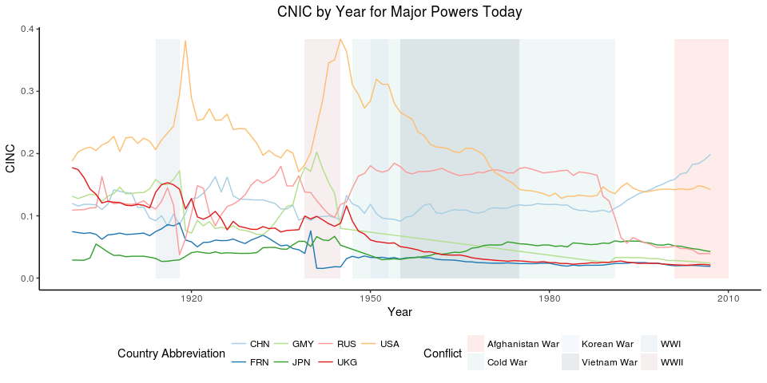

```r
countries <- c("United States of America", "United Kingdom", "France", "Russia","Germany", "Japan", "China")
country_code <- member_alliances$ccode[match(countries, member_alliances$state_name)]
NMC_mp <- filter(NMC, NMC$year %in% all_year)
NMC_mp <- filter(NMC_mp, NMC_mp$ccode %in% country_code)
ggplot() +
  scale_x_continuous(name="Year") +
  scale_y_continuous(name="CINC") +
  labs(color ='Country Abbreviation')+
  geom_rect(data=d, mapping=aes(xmin=x1, xmax=x2, ymin=0, ymax=max(NMC_mp$cinc), fill=Conflict),alpha=0.15) +
  geom_line(data = NMC_mp, aes(x = year, y = cinc, color = stateabb, group = stateabb)) +
  ggtitle("CNIC by Year for Major Powers Today") +
  theme_classic()+
  scale_fill_manual(values=c("salmon", "paleturquoise3", "lightsteelblue2", "lightsteelblue4", "lightsteelblue3", "pink3"))+
  scale_color_brewer(palette="Paired")+
  theme(plot.title = element_text(hjust = .5), legend.position = "bottom")
```

```r
NA
```

As you can see CNIC is changing year by year. What is interesting is that the CNIC spikes for the US right after WWI and WWII where the US had a major role in the outcome of the wars. At the end of WWI, you see Russia’s CNIC dip low but it bounced back to its CNIC before WWI pretty quickly. To explore the trends more, the data was refined to only look at the major participants of each war. For example, with WWI we looked at the CINC values for major players in the Allied Powers and Central Powers a few years before and after the war. We replicated this process for all the events listed above. Below are CINC graphs using this approach for WWI and WWII.

```r
allied <- c("United States of America", "United Kingdom", "Russia", "Japan", "Italy")
allied_ccode <- member_alliances$ccode[match(allied, member_alliances$state_name)]
central <- c("Germany", "Turkey", "Austria-Hungary", "Romania", "Bulgaria")
central_ccode <- member_alliances$ccode[match(central, member_alliances$state_name)]
WWI_range = c(1904:1930)
WWI<- filter(NMC, NMC$year %in% WWI_range)
alliedP<- filter(WWI, WWI$ccode %in% allied_ccode)
alliedP$side = "Allied Powers"
centralP<- filter(WWI, WWI$ccode %in% central_ccode)
centralP$side = "Central Powers "
WWI <-rbind(alliedP, centralP)
ww1 <- ggplot() +
  labs(color ='Country Abbreviation')+
  xlab("Year") +
  ylab("CNIC")+
  geom_rect(data=d, mapping=aes(xmin=1914, xmax=1918, ymin=0, ymax=.4),alpha=0.05, fill ="salmon") +
  geom_line(data = WWI, aes(x = year, y = cinc, color = stateabb, group = stateabb)) +
  facet_wrap(~side) +
  theme_classic()+
  scale_color_brewer(palette="Paired")+
  ggtitle("CNIC Score: WWI Major Players ")+
   theme(plot.title = element_text(hjust = .5),legend.position="right")
allies <- c("United States of America", "United Kingdom", "France", "Russia", "Australia", "Belgium","China", "Denmark", "Greece", "Netherlands")
allies_ccode <- member_alliances$ccode[match(allies, member_alliances$state_name)]
axis <- c("Germany", "Italy", "Japan", "Hungary", "Romania", "Bulgaria")
axis_ccode <- member_alliances$ccode[match(axis, member_alliances$state_name)]
WWII_range = c(1934:1950)
WWII<- filter(NMC, NMC$year %in% WWII_range)
alliedP<- filter(WWII, WWII$ccode %in% allied_ccode)
alliedP$side = "Allies"
axisP<- filter(WWII, WWII$ccode %in% axis_ccode)
axisP$side = "Axis"
WWII <-rbind(alliedP, axisP)
ww2 <- ggplot() +
  labs(color ='Country Abbreviation')+
  xlab("Year") +
  ylab("CNIC")+
  geom_rect(data=d, mapping=aes(xmin=1939, xmax=1945, ymin=0, ymax=.4),alpha=0.05, fill ="paleturquoise3") +
  geom_line(data = WWII, aes(x = year, y = cinc, color = stateabb, group = stateabb)) +
  facet_wrap(~side) +
  theme_classic()+
  scale_color_brewer(palette="Paired")+
  ggtitle("CNIC Score: WWII Major Players ")+
  theme(plot.title = element_text(hjust = .5),legend.position="right")
```

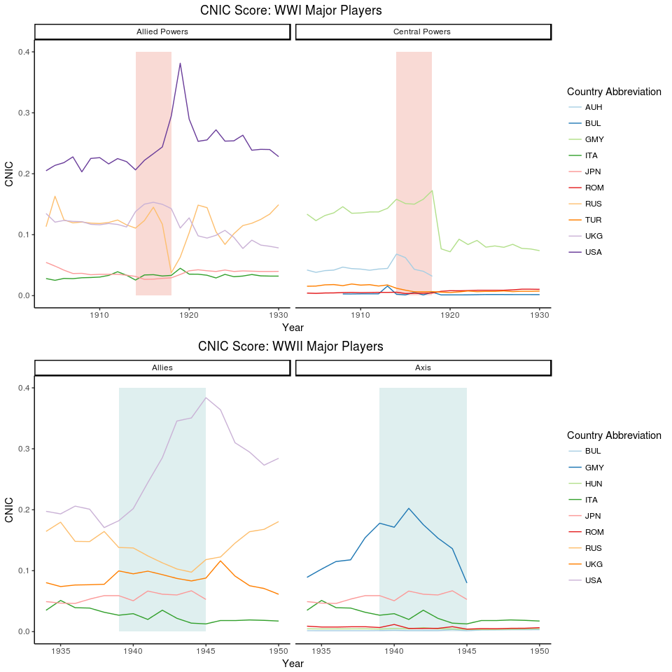

```r
grid.arrange(ww1, ww2, nrow=2)
```

As mentioned, with WWI the US’s CINC spiked right after the war and then began to steadily decrease till the beginning of the WWII. Russia’s CINC dropped but rose again pretty quickly and stayed on a relatively upward trend till WWII. Unlike the US and Russia, United Kingdom’s CINC was steadily decreasing after the war. Italy and Japan’s CINC remained steady. With the Central Powers after WWI, Germany’s CINC dropped but it did not rise again. Turkey’s, Romania’s and Bulgaria’s CINC remained steady. We see the Austria-Hungarian CINC disappear after the war since the Austro-Hungarian empire was dissolved at the end of the war.

With WWII, we see a similar pattern for the US where the CNIC reaches a peak at the end of WWII and steadily decreases till the Korean war. Russia also shows a similar pattern to WWI where its CINC score reaches a low point towards the end of WWII and then continues to steadily increase till the Korean war. The UK also follows a similar pattern where it CINC peaks right after the war and then steadily decreases throughout the Cold War time period. With the Axis powers, Germany’s and Japan’s CINC drops off.

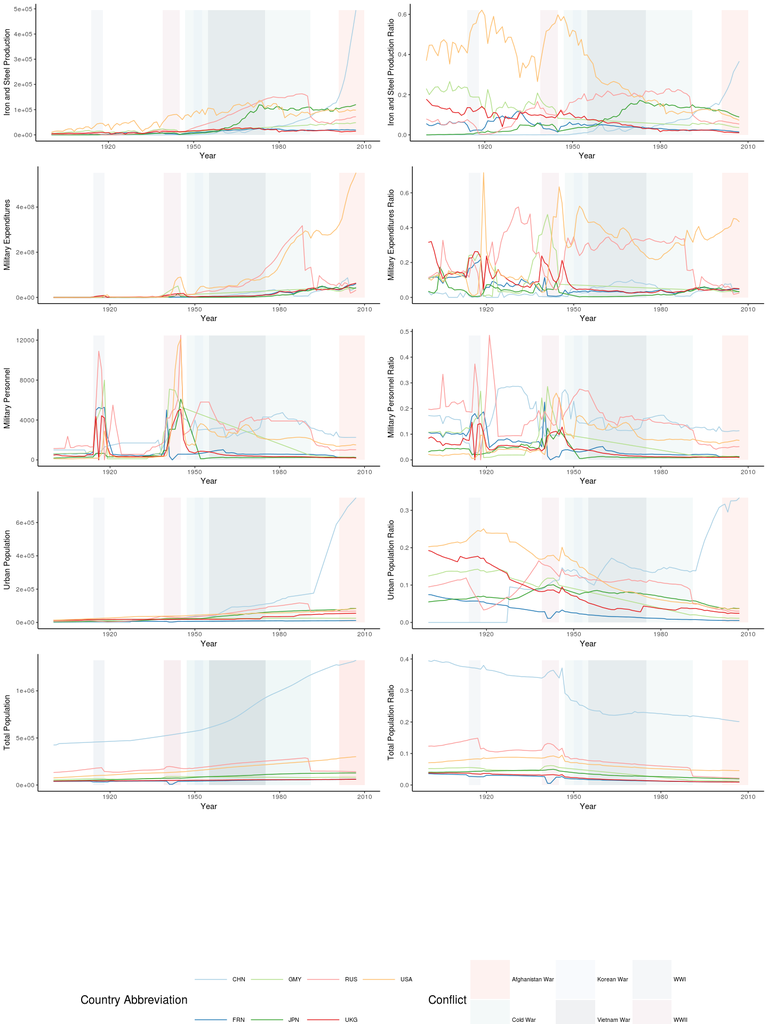

```r
grid.arrange(arrangeGrob(ias, ias_r, mex, mex_r, mip, mip_r, urp, urp_r, top, top_r + theme(plot.title = element_text(hjust = .5), legend.position="none"),nrow=6, ncol =2),mylegend, heights=c(10,1/2))
```

```r
#grid.arrange(ias, ias_r, mex, mex_r, mip, mip_r, urp, urp_r, top, top_r, nrow=6)
```

We looked at both the ratio in addition to the actual value because the all the values gradually increased over time but the ratios show performance relative to the other countries.

With the Iron and Steel Production ratio, you can see that it follows to same pattern for the US and its CINC during this time period with peaks after the war and decreasing till the next war. Till about the beginning of the Vietnam War, roughly 1955, the US dominated the world in Iron and Steel production and so this value had huge impact the US’s CINC score. Generally, during most wars, the US has the most military production

To get even more into detail and context around certain characteristics, we want to look at specific events like pearl harbor or China’s invasion of Malaysia and other pivotal moments in wars to see how those events impact the CINC and its various components.

A problem with NMC is that there are many other factors that determine a power of a nation rather than the 6 NMC factors. One of the major considerations that is not taken into account are diplomatic relations and dealings. Diplomatic relations play a major role is the prevention and conclusion of conflicts. With this data, it was not possible to factor that in.

Additionally, another thing to consider is differences in policies between different countries. We see that military expenditures have been increasing for the US since the Cold War but Russia’s military expenditures take a sudden drop at the end of the Cold War. Since then Russia has been cutting military spending till today. Even with its participation in the Afghanistan War, Russia’s military expenditures have not increase. On the contrary, in the US today, politicians are proposing a Federal Budgets with increases in military spending. This difference is due to differences in policies of the countries. Thus the reactions of countries to events will drastically vary based on their policies and it because hard to distinguish an overall pattern.

Another drawback of NMC is that it cannot take into account changes in universal priorities. For example, with an increased concern for climate change and scare natural resources, iron and steel production might start to decrease drastically in the future so it may no longer be a valid measure of power. The issue with NMC is that it cannot take such policy concerns and changes into consideration to measure national power.

**Alliances**

**Trade**

**Militarized Interstate Disputes**

## Conclusion

**Discuss limitations and future directions, lessons learned**